# scRNA analysis - Brain organoids

Jyoti

2026-03-26

## scRNA-seq Workflow from the publication: “Functional neuronal circuitry and oscillatory dynamics in human brain organoids”, https://doi.org/10.1038/s41467-022-32115-4

### Importing general libraries

```r
library(tidyverse)
library(dplyr)
library(Matrix)
library(ggplot2)
```

### Importing the dge matrices takes too long because of their size, therefore I imported and saved them as Seurat objects below

```r
# read Drop-seq style DGE (Digital Gene Expression) matrices
dge1 <- read.table("GSM6311611_org1_7mo_gene_exon_tagged.dge.txt",  header = TRUE,  row.names = 1,  sep = "\t", check.names = FALSE)

dge1[1:5, 1:5]
```

```
##          TTATGTCCGAAA GTACTAGCGATT GAGTCGCTGACG CACGTAATATAC ATTCGTCAGCTC
## 7SK                 0            0            0            0            0
## A1BG                0            4            2            0            0
## A1BG-AS1            0            0            0            0            0
## A1CF                1            0            0            0            0
## A2M                 0            1            0            0            0
```

```r
cat(paste0("Dimensions of the dge matrix (organoid 1):","\n","rows (genes) = ", dim(dge1)[1], ", columns (cells) = ", dim(dge1)[2]))
```

```
## Dimensions of the dge matrix (organoid 1):
## rows (genes) = 20781, columns (cells) = 4800
```

```r
# dge2 <- read.table("GSM6311612_org2_7mo_gene_exon_tagged.dge.txt",  header = TRUE,  row.names = 1,  sep = "\t", check.names = FALSE)
# dge3 <- read.table("GSM6311613_org3_7mo_gene_exon_tagged.dge.txt",  header = TRUE,  row.names = 1,  sep = "\t", check.names = FALSE)
#
# # convert to sparse matrix BEFORE Seurat
dge1_sparse <- as(as.matrix(dge1), "dgCMatrix")
dge1_sparse[1:5,1:5]
```

```
## 5 x 5 sparse Matrix of class "dgCMatrix"
##          TTATGTCCGAAA GTACTAGCGATT GAGTCGCTGACG CACGTAATATAC ATTCGTCAGCTC
## 7SK                 .            .            .            .            .
## A1BG                .            4            2            .            .
## A1BG-AS1            .            .            .            .            .
## A1CF                1            .            .            .            .
## A2M                 .            1            .            .            .
```

```r
# dge2_sparse <- as(as.matrix(dge2), "dgCMatrix")
# dge3_sparse <- as(as.matrix(dge3), "dgCMatrix")
#
# colnames(dge1_sparse) <- paste0("org1-", colnames(dge1_sparse))
# colnames(dge2_sparse) <- paste0("org2-", colnames(dge2_sparse))
# colnames(dge3_sparse) <- paste0("org3-", colnames(dge3_sparse))


library(Seurat)
cat(paste0("R version: ", R.version.string))
```

```
## R version: R version 4.4.1 (2024-06-14 ucrt)
```

```r
cat(paste0("Seurat version: ",packageVersion("Seurat")))
```

```
## Seurat version: 5.4.0
```

```r
# # create Seurat objects
# seurat1 <- CreateSeuratObject(counts = dge1, project = "org1")
# seurat2 <- CreateSeuratObject(counts = dge2, project = "org2")
# seurat3 <- CreateSeuratObject(counts = dge3, project = "org3")
#
# #View(seurat1@meta.data)
#
# # save seurat objects (as R objects)
# saveRDS(seurat1, file="GSM6311611_org1_7mo_gene_exon_tagged.seurat.RDS")
# saveRDS(seurat2, file="GSM6311612_org2_7mo_gene_exon_tagged.seurat.RDS")
# saveRDS(seurat3, file="GSM6311613_org3_7mo_gene_exon_tagged.seurat.RDS")
```

### An individual Seurat object was generated for each sample, and objects were merged using the Seurat merge function. Cells with <300 genes detected were filtered out, as were cells with >10% mitochondrial gene content.

```r
# import seurat objects
seurat1 = readRDS("GSM6311611_org1_7mo_gene_exon_tagged.seurat.RDS")
seurat2 = readRDS("GSM6311612_org2_7mo_gene_exon_tagged.seurat.RDS")
seurat3 = readRDS("GSM6311613_org3_7mo_gene_exon_tagged.seurat.RDS")

# merge Seurat objects
merged <- merge(x = seurat1, y = list(seurat2, seurat3)) #, add.cell.ids = c("org1", "org2", "org3"))
print(merged)
```

```
## An object of class Seurat
## 23503 features across 14400 samples within 1 assay
## Active assay: RNA (23503 features, 0 variable features)
##  2 layers present: counts, data
```

```r
head(merged@meta.data, 5)
```

```
##                   orig.ident nCount_RNA nFeature_RNA
## org1-TTATGTCCGAAA       org1      21026         5710
## org1-GTACTAGCGATT       org1      25660         6619
## org1-GAGTCGCTGACG       org1      15238         5197
## org1-CACGTAATATAC       org1      13896         4688
## org1-ATTCGTCAGCTC       org1      22375         6127
```

```r
##################################################
# # calculate mitochondrial percentage
# genes <- rownames(merged[["RNA"]])
# cells <- colnames(merged[["RNA"]])
# counts <- merged[["RNA"]]$counts
#
# # mitochondrial genes
# mt_genes <- grep("^MT-", genes, value = TRUE)
#
# # mictocondrial percentage of first cell
# dimnames(counts) <- list(genes, cells)
# sum(counts[mt_genes,1])/sum(counts[,1])
##################################################

merged <- PercentageFeatureSet(merged, pattern = "^MT-", col.name = 'percent.mt')
head(merged@meta.data, 5)
```

```
##                   orig.ident nCount_RNA nFeature_RNA percent.mt
## org1-TTATGTCCGAAA       org1      21026         5710   2.011795
## org1-GTACTAGCGATT       org1      25660         6619   2.692907
## org1-GAGTCGCTGACG       org1      15238         5197   3.438771
## org1-CACGTAATATAC       org1      13896         4688   1.734312
## org1-ATTCGTCAGCTC       org1      22375         6127   2.122905
```

```r
merged_temp <- subset(merged, subset = percent.mt > 10)
head(merged_temp@meta.data, 5)
```

```
##                   orig.ident nCount_RNA nFeature_RNA percent.mt
## org1-CGGTTTAAGTAG       org1        390          267   10.51282
## org1-TAGAAGGGGGAA       org1        805          508   14.78261
## org1-CCTTACTTATCC       org1        614          430   12.70358
## org1-TGGCATTTCTAA       org1        261          139   34.09962
## org1-TTACACACTACT       org1        501          340   12.77445
```

```r
# filter cells (done as the publication, but generally good to filter nCounts_RNA as well)
merged <- subset(merged, subset = nFeature_RNA >= 300 & percent.mt <= 10)
print(merged)
```

```
## An object of class Seurat
## 23503 features across 6197 samples within 1 assay
## Active assay: RNA (23503 features, 0 variable features)
##  2 layers present: counts, data
```

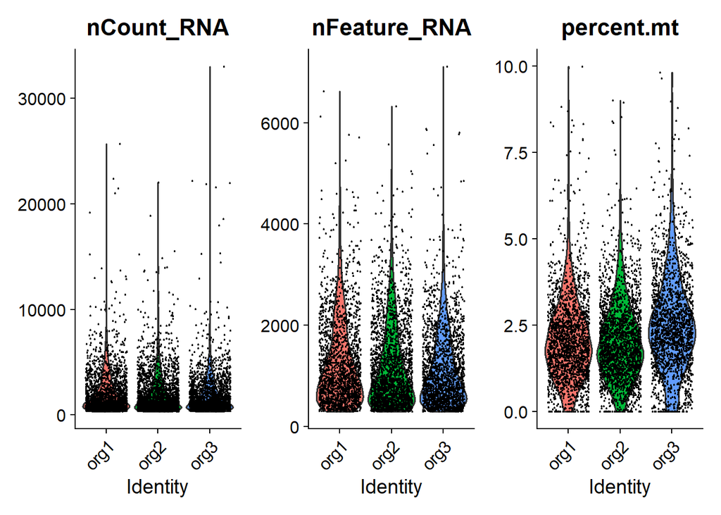

```r
VlnPlot(merged, features = c("nCount_RNA", "nFeature_RNA", "percent.mt"))
```

### Counts data were log-normalized using the default NormalizeData function and the default scale of 1e4.

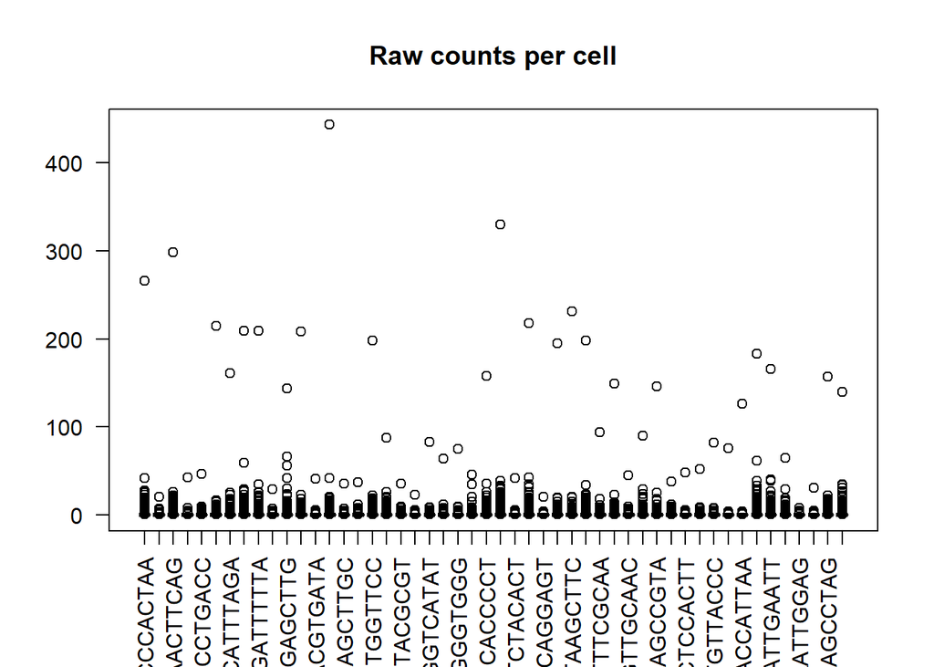

```r
# log-normalize counts (default parameters)
merged <- NormalizeData(merged, normalization.method = "LogNormalize", scale.factor = 10000)

# Pick 50 cells
cells_to_plot <- sample(colnames(merged), 50)

# Extract counts as a regular matrix
counts_mat <- as.matrix(GetAssayData(merged, layer = "counts")[, cells_to_plot])
data_mat   <- as.matrix(GetAssayData(merged, layer = "data")[, cells_to_plot])

# Boxplot for raw counts
boxplot(counts_mat,
        main = "Raw counts per cell",
        las = 2)
```

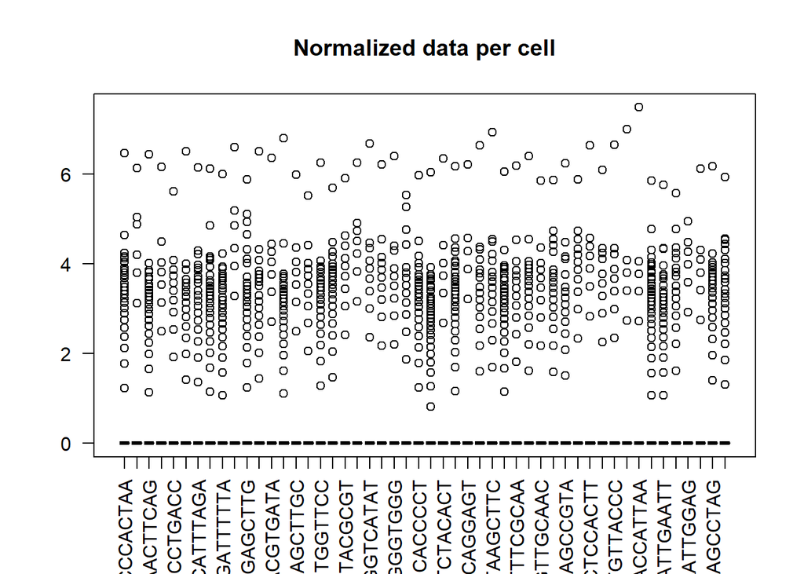

```r
# Boxplot for normalized data
boxplot(data_mat,
        main = "Normalized data per cell",
        las = 2)
```

### The top 3000 variable genes were identified using the Seurat FindVariableFeatures function (election.method=“vst”, nfeatures=3000), followed by scaling and centering using the default ScaleData function.

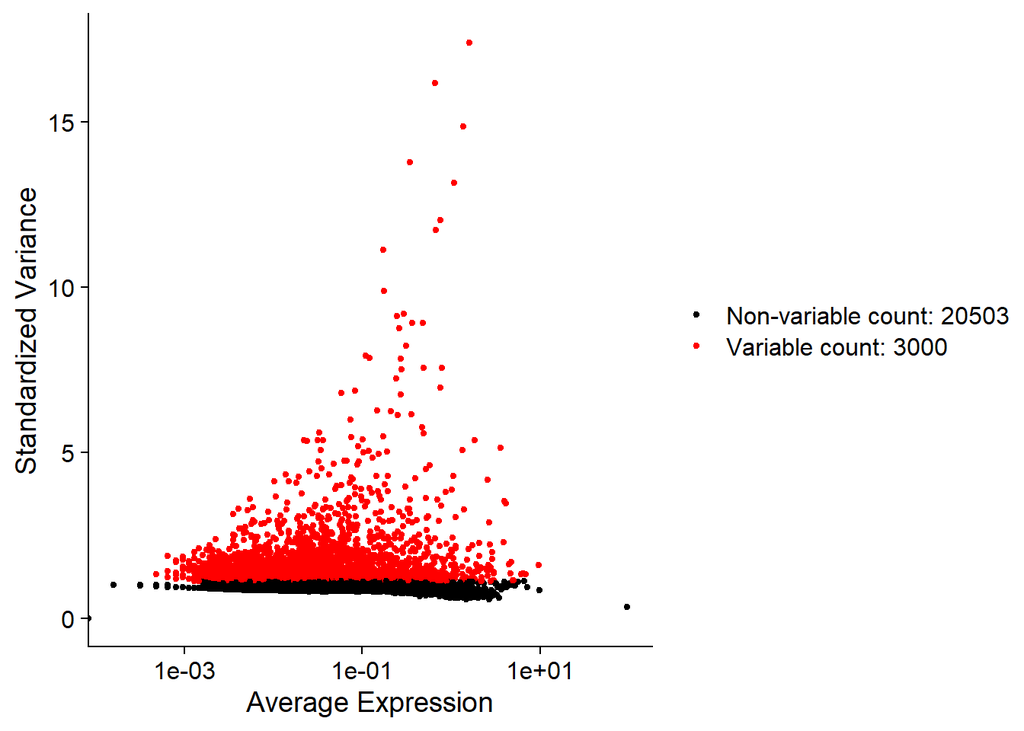

```r
# identify highly variable genes
merged <- FindVariableFeatures(merged, selection.method = "vst", nfeatures = 3000)
VariableFeaturePlot(merged)
```

```r
## runs scaling on 3000 identified variable features
merged <- ScaleData(merged)
```

### Principal Components Analysis was carried out on the scaled expression values of the 3000 top variable genes, and the cells were clustered using the first 30 principal components (PCs) as input in the FindNeighbors function, and a resolution of 0.4 in the FindClusters function. Non-linear dimensionality reduction was performed by running UMAP on the first 30 PCs.

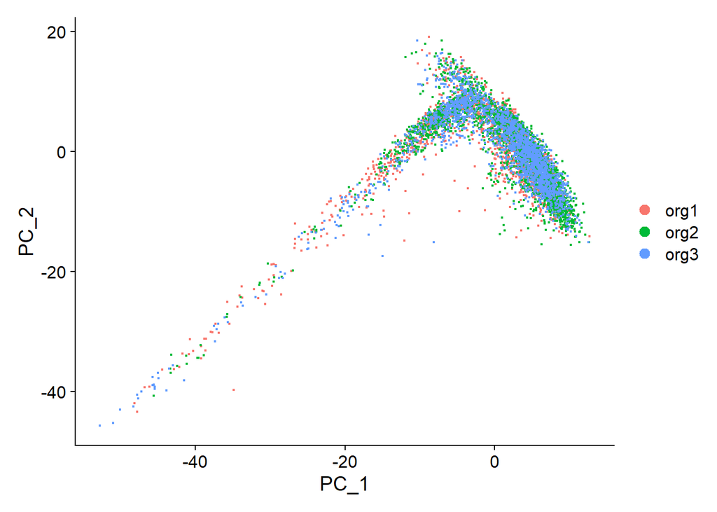

```r
# PCA on the 3000 variable genes

merged <- RunPCA(merged, features = VariableFeatures(object = merged))

# Plotting PCA to visualize
DimPlot(merged, reduction = 'pca', dims = c(1,2))
```

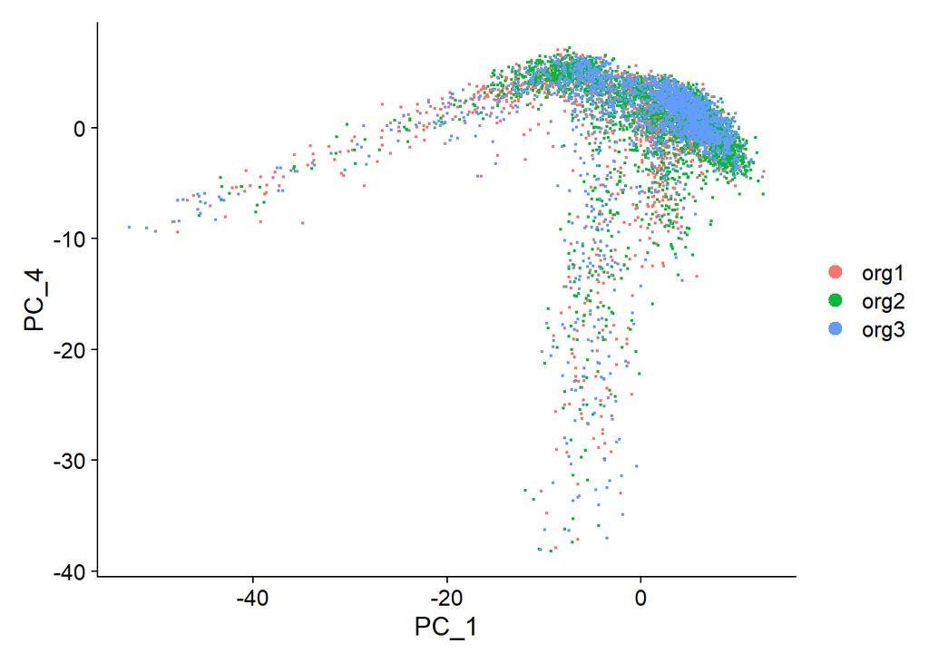

```r
DimPlot(merged, reduction = 'pca', dims = c(1,4))
```

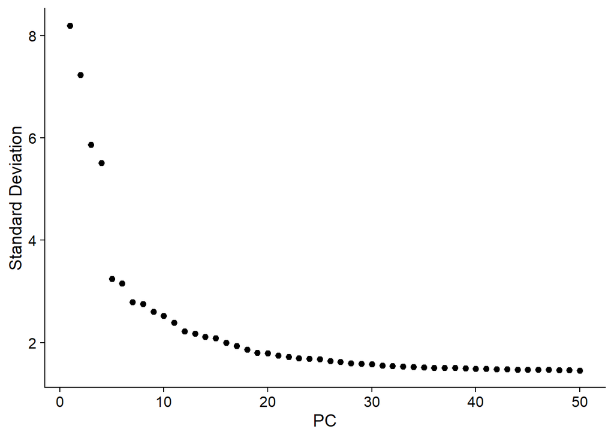

```r
# Inspect variance explained
ElbowPlot(merged, ndims = 50, reduction = 'pca')
```

```r
# build SNN graph using first 30 PCs

merged <- FindNeighbors(merged, dims = 1:30)

# cluster cells at resolution 0.4

merged <- FindClusters(merged, resolution = 0.4) # number of clusters increases with resolution
```

```
## Modularity Optimizer version 1.3.0 by Ludo Waltman and Nees Jan van Eck
##
## Number of nodes: 6197
## Number of edges: 230440
##
## Running Louvain algorithm...
## Maximum modularity in 10 random starts: 0.8867
## Number of communities: 10
## Elapsed time: 1 seconds
```

```r
# check the cluster the cells belong to
Idents(merged)[1:10]
```

```
## org1-TTATGTCCGAAA org1-GTACTAGCGATT org1-GAGTCGCTGACG org1-CACGTAATATAC
##                 3                 3                 3                 1
## org1-ATTCGTCAGCTC org1-ATTCAGTTCGAA org1-AAACCCATCTTC org1-GCCGATTATACA
##                 3                 1                 1                 3
## org1-ACAGGCTCAAGA org1-GACTTGCAATGA
##                 9                 1
## Levels: 0 1 2 3 4 5 6 7 8 9
```

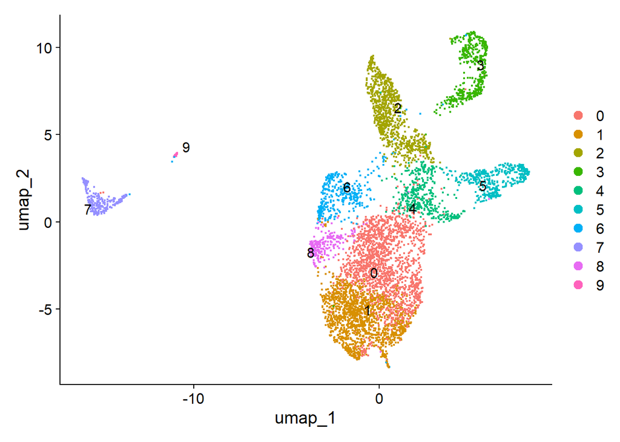

```r
merged <- RunUMAP(merged, dims = 1:30, seed.use = 42)
DimPlot(merged, reduction = 'umap', label = TRUE, repel = TRUE)
```

```r
library(DoubletFinder)
cat(paste0("DoubletFinder version: ",packageVersion("DoubletFinder")))
```

```
## DoubletFinder version: 2.0.4
```

```r
# Tests many values of pK (neighborhood size) to see which best separates real cells from artificial doublets.
sweep.res <- paramSweep(merged, PCs = 1:30, sct = FALSE) ##sct = if scTransform was used
```

```
## [1] "Creating artificial doublets for pN = 5%"
## [1] "Creating Seurat object..."
## [1] "Normalizing Seurat object..."
```

```
## [1] "Finding variable genes..."
```

```
## [1] "Scaling data..."
```

[output not shown]

[output cut: 23 more lines]

```
## [1] "Finding variable genes..."
```

```
## [1] "Scaling data..."
```

[output not shown]

[output cut: 23 more lines]

```
## [1] "Finding variable genes..."
```

```
## [1] "Scaling data..."
```

[output not shown]

[output cut: 23 more lines]

```
## [1] "Finding variable genes..."
```

```
## [1] "Scaling data..."
```

[output not shown]

[output cut: 23 more lines]

```
## [1] "Finding variable genes..."
```

```
## [1] "Scaling data..."
```

[output not shown]

[output cut: 23 more lines]

```
## [1] "Finding variable genes..."
```

```
## [1] "Scaling data..."
```

[output not shown]

[output cut: 20 more lines]

```r
## Summarize results
sweep.stats <- summarizeSweep(sweep.res, GT = FALSE)   ## GT = Is ground truth available
#head(sweep.stats, 10)

pk.table <- find.pK(sweep.stats)
```

[figure not shown]

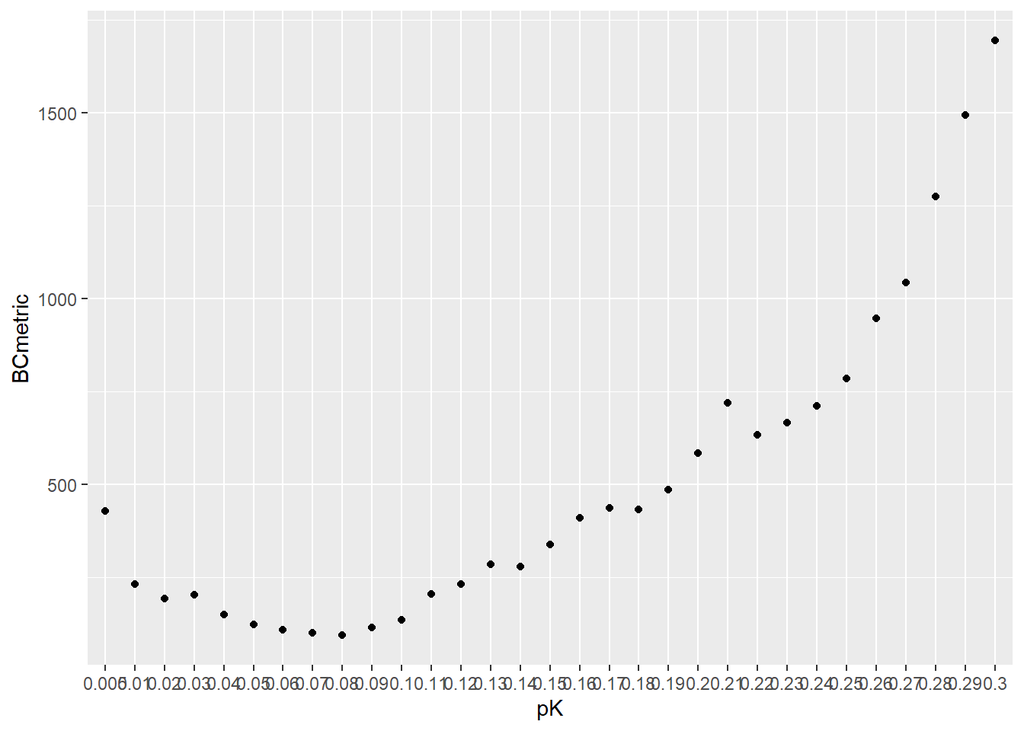

```r
ggplot(pk.table, aes(pK, BCmetric)) + #Bimodality coefficient
  geom_line() + geom_point()
```

```r
# expected doublet rate = 5%
nExp_poi <- round(0.05 * length(merged$RNA_snn_res.0.4))
cat(paste0("Number of doublets expected after 5% doublet rate: ", nExp_poi))
```

```
## Number of doublets expected after 5% doublet rate: 310
```

```r
# Estimate homotypic doublet proportion from clustering
annotations <- merged@meta.data$seurat_clusters
homotypic.prop <- modelHomotypic(annotations)

# adjust expected number for homotypic doublets
nExp_poi.adj <- round(nExp_poi*(1-homotypic.prop))
cat(paste0("Number of doublets expected after adjusting for homotypic doublets: ", nExp_poi.adj))
```

```
## Number of doublets expected after adjusting for homotypic doublets: 258
```

```r
# Run DoubletFinder with chosen pK = 0.61 (neighborhood size)
merged <- doubletFinder(
  merged,
  PCs = 1:30,
  pN = 0.25,
  pK = 0.61,
  nExp = nExp_poi.adj,
  reuse.pANN = FALSE,
  sct = FALSE
)
```

```
## [1] "Creating 2066 artificial doublets..."
## [1] "Creating Seurat object..."
## [1] "Normalizing Seurat object..."
```

```
## [1] "Finding variable genes..."
```

```
## [1] "Scaling data..."
```

```
## [1] "Running PCA..."
## [1] "Calculating PC distance matrix..."
## [1] "Computing pANN..."
## [1] "Classifying doublets.."
```

```r
head(merged@meta.data, 10)
```

```
##                   orig.ident nCount_RNA nFeature_RNA percent.mt RNA_snn_res.0.4
## org1-TTATGTCCGAAA       org1      21026         5710   2.011795               3
## org1-GTACTAGCGATT       org1      25660         6619   2.692907               3
## org1-GAGTCGCTGACG       org1      15238         5197   3.438771               3
## org1-CACGTAATATAC       org1      13896         4688   1.734312               1
## org1-ATTCGTCAGCTC       org1      22375         6127   2.122905               3
## org1-ATTCAGTTCGAA       org1      12852         4495   2.715531               1
## org1-AAACCCATCTTC       org1       9547         4029   2.147271               1
## org1-GCCGATTATACA       org1      13113         4629   1.540456               3
## org1-ACAGGCTCAAGA       org1      19189         5255   1.386211               9
## org1-GACTTGCAATGA       org1      12687         4367   4.327264               1
##                   seurat_clusters pANN_0.25_0.61_258
## org1-TTATGTCCGAAA               3          0.3347222
## org1-GTACTAGCGATT               3          0.3402778
## org1-GAGTCGCTGACG               3          0.3384921
## org1-CACGTAATATAC               1          0.3083333
## org1-ATTCGTCAGCTC               3          0.3305556
## org1-ATTCAGTTCGAA               1          0.2966270
## org1-AAACCCATCTTC               1          0.2902778
## org1-GCCGATTATACA               3          0.3253968
## org1-ACAGGCTCAAGA               9          0.3126984
## org1-GACTTGCAATGA               1          0.2982143
##                   DF.classifications_0.25_0.61_258
## org1-TTATGTCCGAAA                          Doublet
## org1-GTACTAGCGATT                          Doublet
## org1-GAGTCGCTGACG                          Doublet
## org1-CACGTAATATAC                          Doublet
## org1-ATTCGTCAGCTC                          Doublet
## org1-ATTCAGTTCGAA                          Doublet
## org1-AAACCCATCTTC                          Doublet
## org1-GCCGATTATACA                          Doublet
## org1-ACAGGCTCAAGA                          Doublet
## org1-GACTTGCAATGA                          Doublet
```

```r
tail(merged@meta.data, 10)
```

```
##                   orig.ident nCount_RNA nFeature_RNA percent.mt RNA_snn_res.0.4
## org3-CCGACGTGTGAA       org3        403          340  3.9702233               0
## org3-TGTTGAATAGAG       org3        372          308  7.2580645               0
## org3-GGGTGCTCTCTC       org3        475          395  1.2631579               5
## org3-CGGGGTTCTGGA       org3        433          355  4.1570439               0
## org3-GCCTAGGGCCTT       org3        383          318  0.7832898               0
## org3-GGGGAGTGCCTC       org3        413          352  2.1791768               4
## org3-TACCCAGTTATA       org3        349          302  4.5845272               3
## org3-AGGGTTACCTAT       org3        366          309  3.8251366               0
## org3-ATTGGTGTTTAC       org3        879          685  1.5927190               3
## org3-AACCCAGTTGTA       org3        839          658  3.2181168               3
##                   seurat_clusters pANN_0.25_0.61_258
## org3-CCGACGTGTGAA               0          0.1664683
## org3-TGTTGAATAGAG               0          0.1648810
## org3-GGGTGCTCTCTC               5          0.1755952
## org3-CGGGGTTCTGGA               0          0.1704365
## org3-GCCTAGGGCCTT               0          0.1662698
## org3-GGGGAGTGCCTC               4          0.1720238
## org3-TACCCAGTTATA               3          0.1928571
## org3-AGGGTTACCTAT               0          0.1656746
## org3-ATTGGTGTTTAC               3          0.2355159
## org3-AACCCAGTTGTA               3          0.2232143
##                   DF.classifications_0.25_0.61_258
## org3-CCGACGTGTGAA                          Singlet
## org3-TGTTGAATAGAG                          Singlet
## org3-GGGTGCTCTCTC                          Singlet
## org3-CGGGGTTCTGGA                          Singlet
## org3-GCCTAGGGCCTT                          Singlet
## org3-GGGGAGTGCCTC                          Singlet
## org3-TACCCAGTTATA                          Singlet
## org3-AGGGTTACCTAT                          Singlet
## org3-ATTGGTGTTTAC                          Singlet
## org3-AACCCAGTTGTA                          Singlet
```

### After filtering out the doublets as identified by DoubletFinder, counts data were extracted, and a new Seurat object was generated.

```r
# Filter out doublets
filtered <- subset(merged, subset = DF.classifications_0.25_0.61_258 == "Singlet")

# Extract counts and create new Seurat object
filtered_counts <- GetAssayData(filtered, layer = "counts")
seurat_new <- CreateSeuratObject(counts = filtered_counts, project = 'organoid')
seurat_new$orig.ident = substr(colnames(filtered), 1, 4)
```

```r
# Normalize, variable features, scaling
seurat_new <- NormalizeData(seurat_new, normalization.method = "LogNormalize", scale.factor = 10000)
seurat_new <- FindVariableFeatures(seurat_new, selection.method = "vst", nfeatures = 3000)
seurat_new <- ScaleData(seurat_new)

# PCA
seurat_new <- RunPCA(seurat_new, features = VariableFeatures(object = seurat_new))

# Clustering at multiple resolutions
seurat_new <- FindNeighbors(seurat_new, dims = 1:32)
seurat_new <- FindClusters(seurat_new, resolution = c(0.4))
```

```
## Modularity Optimizer version 1.3.0 by Ludo Waltman and Nees Jan van Eck
##
## Number of nodes: 5939
## Number of edges: 222620
##
## Running Louvain algorithm...
## Maximum modularity in 10 random starts: 0.8852
## Number of communities: 9
## Elapsed time: 1 seconds
```

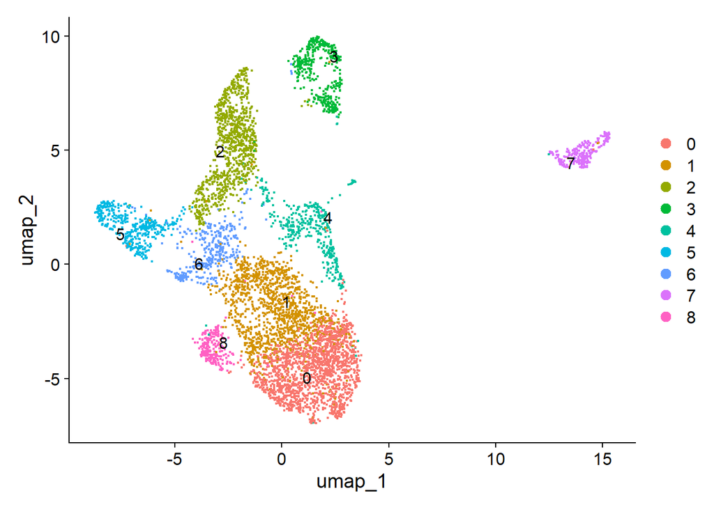

```r
# UMAP
seurat_new <- RunUMAP(seurat_new, dims = 1:32, seed.use = 42)
DimPlot(seurat_new, reduction = 'umap', label = TRUE, repel = TRUE)
```

```r
### Changing the cluster-numbers to match the manuscript-labeling so that they can be compared later
### This clustering order can change each time, therefore it is important to first check umap and compare it with the manuscript's umap and then change the labels if necessary
new_ids <- c(
  "0" = "0",
  "1" = "1",
  "2" = "2",
  "3" = "3",
  "4" = "6",
  "5" = "4",
  "6" = "5",
  "7" = "8",
  "8" = "7"
)

Idents(seurat_new) <- plyr::mapvalues(
  x = as.character(Idents(seurat_new)),
  from = names(new_ids),
  to   = new_ids
)

Idents(seurat_new) <- factor(
  Idents(seurat_new),
  levels = sort(as.character(unique(Idents(seurat_new))))
)

# Check clusters at resolution 0.4
table(seurat_new$seurat_clusters)
```

```
##
##    0    1    2    3    4    5    6    7    8
## 1661 1297  944  399  398  397  356  256  231
```

### Cluster identities changed

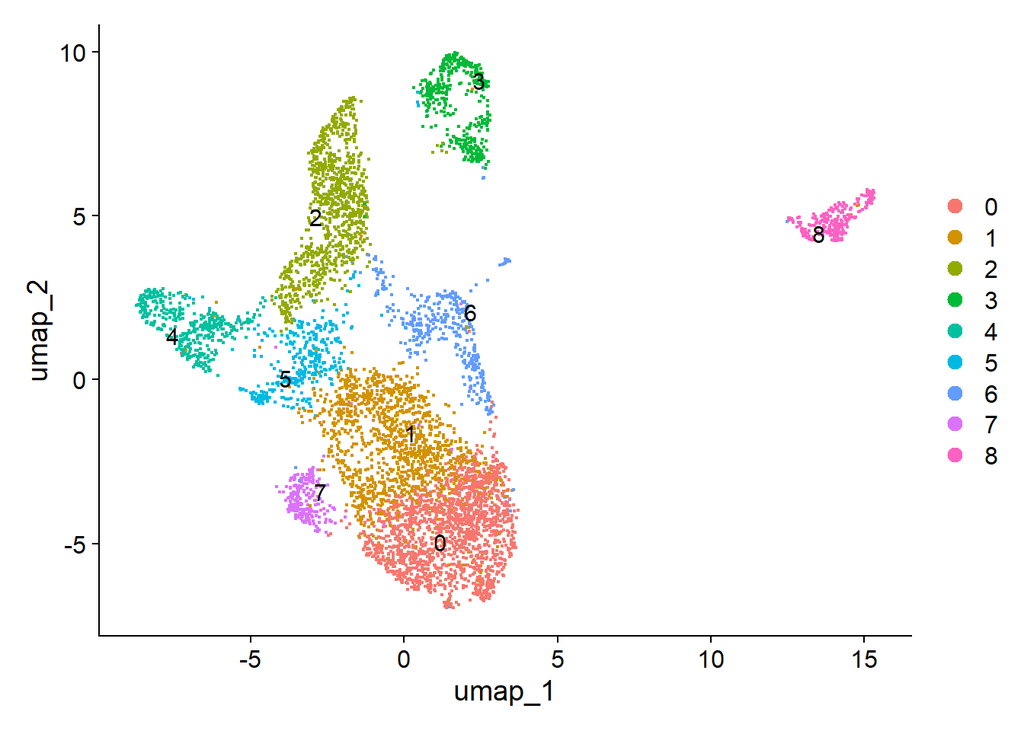

```r
# UMAP
seurat_new <- RunUMAP(seurat_new, dims = 1:32, seed.use = 42)
DimPlot(seurat_new, reduction = 'umap', label = TRUE, repel = TRUE)
```

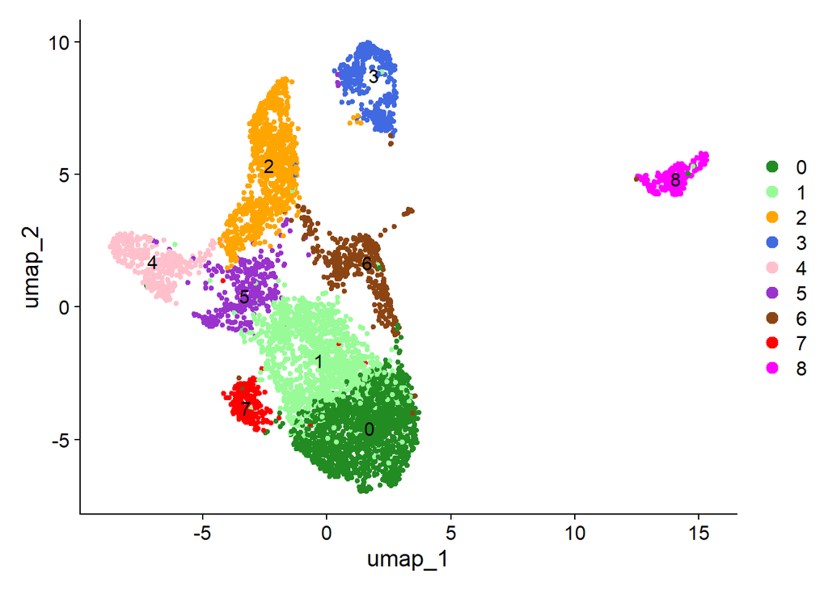

```r
cluster_colors <- c(
  "0" = "forestgreen",
  "1" = "palegreen",
  "2" = "orange",
  "3" = "royalblue",
  "4" = "pink",
  "5" = "darkorchid3",
  "6" = "chocolate4",
  "7" = "red",
  "8" = "magenta"
)

#png(paste0('_umap_',pk_val,'.png'), width = 7.5, height = 5, units = 'in', res = 300)
DimPlot(seurat_new, reduction = 'umap', label = TRUE, cols = cluster_colors, pt.size = 1)
```

```r
#dev.off()
```

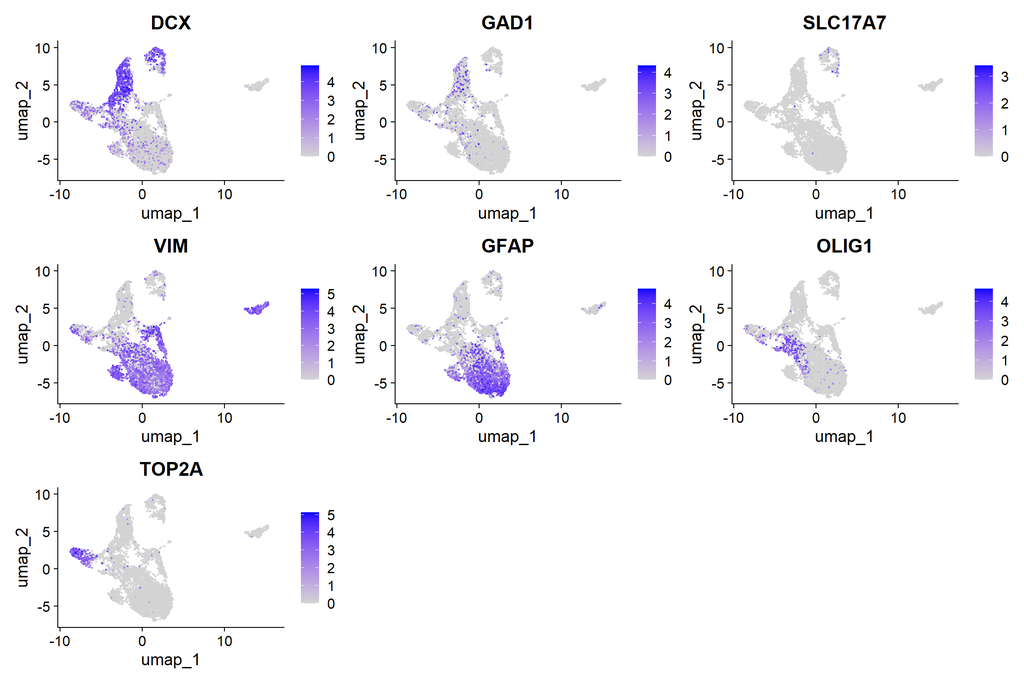

```r
# Markers genes from supplementary figure 5
FeaturePlot(seurat_new, features = c('DCX', 'GAD1', 'SLC17A7', 'VIM', 'GFAP', 'OLIG1', 'TOP2A'))
```

### Marker genes were identified for each cluster using the Wilcoxon rank sum test implemented the FindMarkers function, with a logFC threshold of 0.25 and Bonferroni correction for multiple testing, confirming and refining our initial cell type annotation using canonical marker genes.

```r
# Find marker genes for all clusters
markers <- FindAllMarkers(seurat_new, test.use = "wilcox", logfc.threshold = 0.25, p.adjust.methods ="bonferroni")

# To save significant markers
export_cluster_markers = markers %>% group_by(cluster) %>% dplyr::filter(p_val_adj < 0.05)
#write.csv(export_cluster_markers, paste0("SignificantMarkers_", pk_val,".csv"))

# Keep significant markers
significant_markers <- markers %>% group_by(cluster) %>% dplyr::filter(p_val_adj < 0.05) %>% slice_min(order_by = p_val_adj, n = 5, with_ties = FALSE)
```

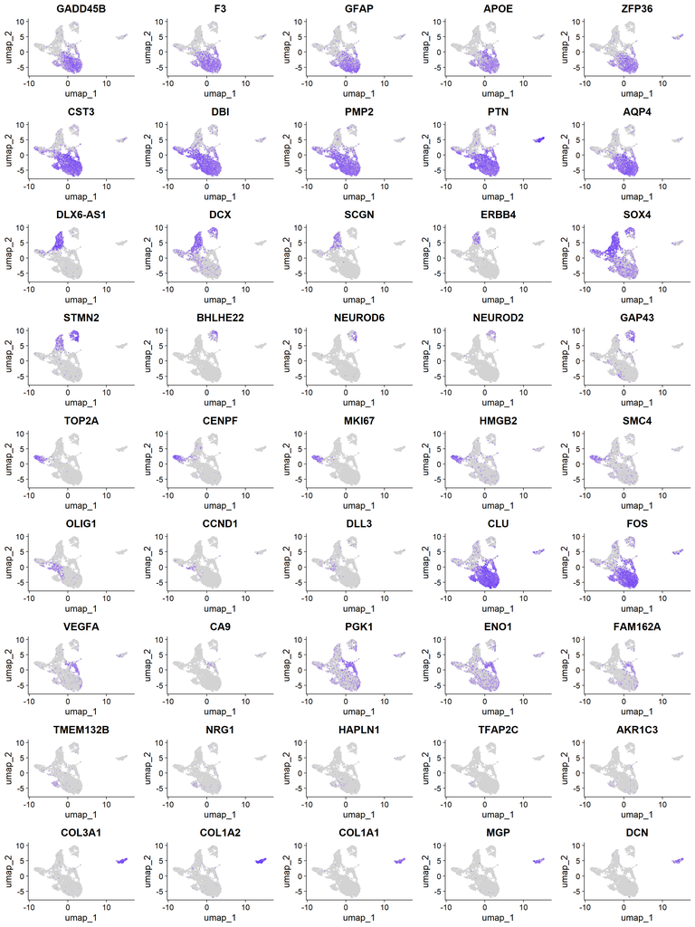

```r
# Plot top 5 of all clusters
genes = significant_markers$gene
expr_mat <- GetAssayData(seurat_new, layer = "data")[genes, ]
global_min <- min(expr_mat)
global_max <- max(expr_mat)

# FeaturePlot with fixed scale for all genes
plots <- FeaturePlot(seurat_new, features = genes, combine = FALSE)

plots <- lapply(plots, function(p){
  p + scale_color_gradientn(
    colors = c("lightgrey", "blue"),
    limits = c(global_min, global_max)
  ) + NoLegend()
})

cowplot::plot_grid(plotlist = plots, ncol = 5)
```

### Heatmap of the top 50 marker genes for each cluster, colored by z-scaled expression values.

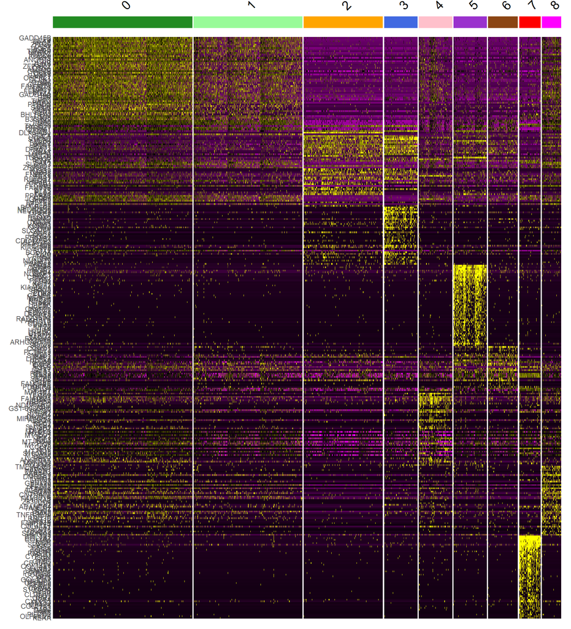

```r
top50 <- markers %>%
  group_by(cluster) %>%
  dplyr::filter(p_val_adj < 0.05) %>%
  slice_min(order_by = p_val_adj, n = 50, with_ties = FALSE)

# Heatmap of top 50 genes from each cluster (z-scaled expression)
seurat_new <- ScaleData(seurat_new, features = unique(top50$gene))

DoHeatmap(
  seurat_new,
  features = unique(top50$gene),
  group.by = "seurat_clusters",
  group.colors = cluster_colors
) + NoLegend()
```

### Forebrain Features

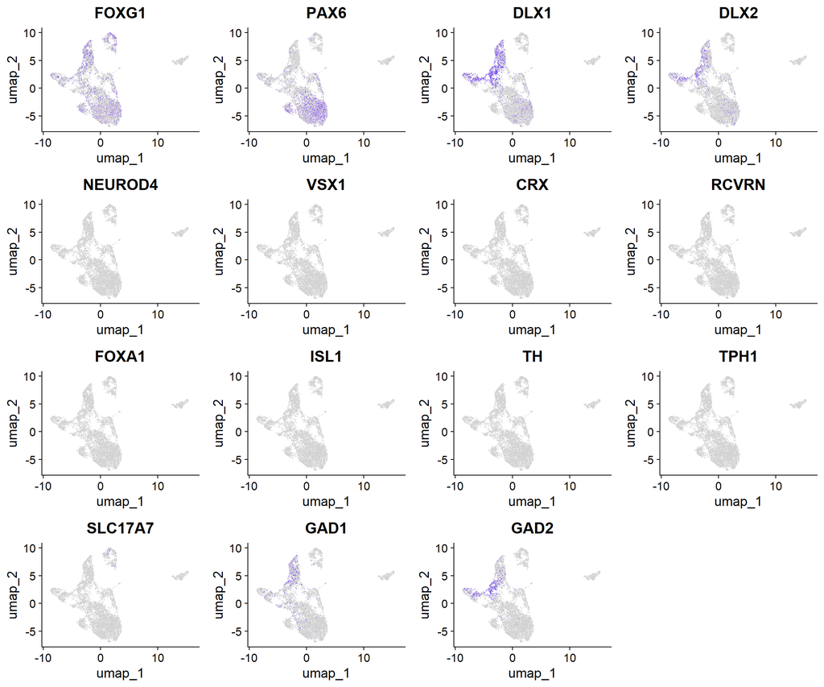

```r
# Forebrain
genes = c("FOXG1", "PAX6", "DLX1", "DLX2"
          , "NEUROD4", "VSX1", "CRX", "RCVRN"
          , "FOXA1", "ISL1", "TH", "TPH1"
          , "SLC17A7", "GAD1", "GAD2")

# Get global min/max across the selected genes
expr_mat <- GetAssayData(seurat_new, layer = "data")[genes, ]
global_min <- min(expr_mat)
global_max <- max(expr_mat)

# FeaturePlot with fixed scale for all genes
plots <- FeaturePlot(seurat_new, features = genes, combine = FALSE, pt.size = .002)

plots <- lapply(plots, function(p){
  p + scale_color_gradientn(
    colors = c("lightgrey", "blue"),
    limits = c(global_min, global_max)
  ) + NoLegend()
})

cowplot::plot_grid(plotlist = plots, ncol = 4)
```

### GlutamateReceptors

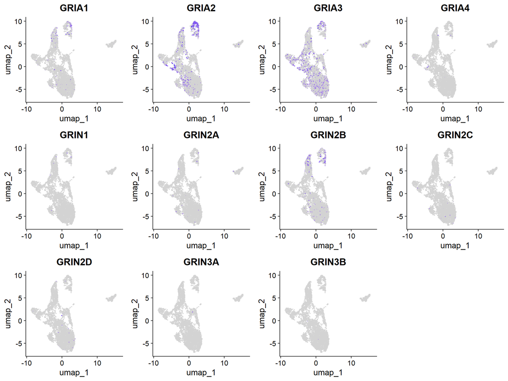

```r
#GlutamateReceptors
genes = c("GRIA1", "GRIA2", "GRIA3", "GRIA4"
          , "GRIN1", "GRIN2A", "GRIN2B", "GRIN2C"
          , "GRIN2D", "GRIN3A", "GRIN3B")

# Get global min/max across the selected genes
expr_mat <- GetAssayData(seurat_new, layer = "data")[genes, ]
global_min <- min(expr_mat)
global_max <- max(expr_mat)

# FeaturePlot with fixed scale for all genes
plots <- FeaturePlot(seurat_new, features = genes, combine = FALSE)

plots <- lapply(plots, function(p){
  p + scale_color_gradientn(
    colors = c("lightgrey", "blue"),
    limits = c(global_min, global_max)
  ) + NoLegend()
})

cowplot::plot_grid(plotlist = plots, ncol = 4)
```

### GABAReceptors

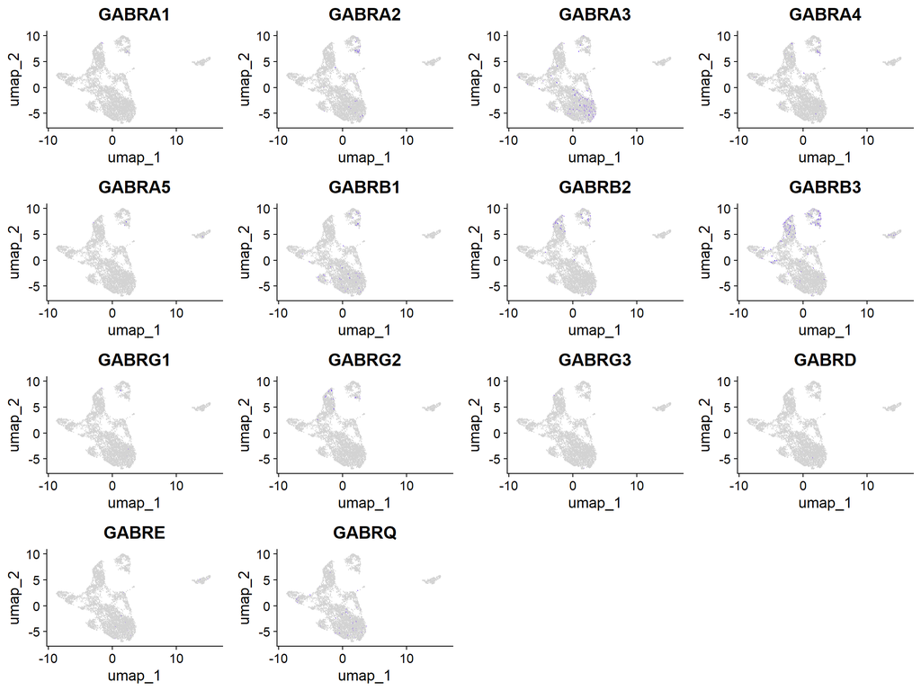

```r
#GABAReceptors
genes = c("GABRA1", "GABRA2", "GABRA3", "GABRA4"
          , "GABRA5", "GABRB1", "GABRB2", "GABRB3"
          , "GABRG1", "GABRG2", "GABRG3"
          , "GABRD", "GABRE", "GABRQ")

# Get global min/max across the selected genes
expr_mat <- GetAssayData(seurat_new, layer = "data")[genes, ]
global_min <- min(expr_mat)
global_max <- max(expr_mat)

# FeaturePlot with fixed scale for all genes
plots <- FeaturePlot(seurat_new, features = genes, combine = FALSE, pt.size = 0.0002)

plots <- lapply(plots, function(p){
  p + scale_color_gradientn(
    colors = c("lightgrey", "blue"),
    limits = c(global_min, global_max)
  ) + NoLegend()
})

cowplot::plot_grid(plotlist = plots, ncol = 4)
```